# Phenology project_update(v4)

Pat Dumandan

4/20/2021

### PB MODELS

##### PB MALES IN CONTROL

```
##
## Family: binomial
## Link function: logit
##
## Formula:
## proportion ~ s(month, bs = "cc", k = 12) + s(year) + s(ndvi) +
##     s(precipitation)
##
## Parametric coefficients:
##             Estimate Std. Error z value Pr(>|z|)
## (Intercept)  -2.3236     0.1324  -17.55   <2e-16 ***
## ---
## Signif. codes:  0 '***' 0.001 '**' 0.01 '*' 0.05 '.' 0.1 ' ' 1
##
## Approximate significance of smooth terms:
##                    edf Ref.df Chi.sq  p-value
## s(month)         3.372 10.000 25.199 1.73e-06 ***
## s(year)          3.061  3.762  3.422    0.327
## s(ndvi)          2.967  3.704  5.079    0.216
## s(precipitation) 2.597  3.235  4.796    0.227
## ---
## Signif. codes:  0 '***' 0.001 '**' 0.01 '*' 0.05 '.' 0.1 ' ' 1
##
## R-sq.(adj) =  0.269   Deviance explained = 34.3%
## -REML = 159.59  Scale est. = 1         n = 157
```

```
##
## Family: binomial
## Link function: logit
##
## Formula:
## proportion ~ s(month, bs = "cc", k = 12) + s(year) + s(ndvi) +
##     s(precipitation) + s(bmass_DM)
##
## Parametric coefficients:
##             Estimate Std. Error z value Pr(>|z|)
## (Intercept)  -2.3178     0.1351  -17.16   <2e-16 ***
## ---
## Signif. codes:  0 '***' 0.001 '**' 0.01 '*' 0.05 '.' 0.1 ' ' 1
##
## Approximate significance of smooth terms:
##                    edf Ref.df Chi.sq  p-value
## s(month)         3.446 10.000 26.301 9.96e-07 ***
## s(year)          3.274  4.022  5.542    0.233
## s(ndvi)          2.804  3.511  4.392    0.257
## s(precipitation) 2.774  3.456  5.641    0.187
## s(bmass_DM)      1.000  1.000  0.581    0.446
## ---
## Signif. codes:  0 '***' 0.001 '**' 0.01 '*' 0.05 '.' 0.1 ' ' 1
##
## R-sq.(adj) =  0.271   Deviance explained = 35.1%
## -REML = 160.49  Scale est. = 1         n = 157
```

```
##
## Family: binomial
## Link function: logit
##
## Formula:
## proportion ~ s(month, bs = "cc", k = 12) + s(year) + s(ndvi) +
##     s(precipitation) + s(bmass_DM) + s(bmass_PB) + s(bmass_PP)
##
## Parametric coefficients:
##             Estimate Std. Error z value Pr(>|z|)
## (Intercept)  -2.3028     0.1378  -16.71   <2e-16 ***
## ---
## Signif. codes:  0 '***' 0.001 '**' 0.01 '*' 0.05 '.' 0.1 ' ' 1
##
## Approximate significance of smooth terms:
##                    edf Ref.df Chi.sq  p-value
## s(month)         3.455 10.000 26.105 6.11e-07 ***
## s(year)          2.780  3.483  5.874   0.2406
## s(ndvi)          2.777  3.470  5.129   0.1980
## s(precipitation) 2.099  2.593  2.932   0.4554
## s(bmass_DM)      1.000  1.000  0.016   0.8999
## s(bmass_PB)      1.000  1.000  4.863   0.0275 *
## s(bmass_PP)      1.775  2.241  6.890   0.0422 *
## ---
## Signif. codes:  0 '***' 0.001 '**' 0.01 '*' 0.05 '.' 0.1 ' ' 1
##
## R-sq.(adj) =  0.291   Deviance explained = 37.3%
## -REML = 159.36  Scale est. = 1         n = 157
```

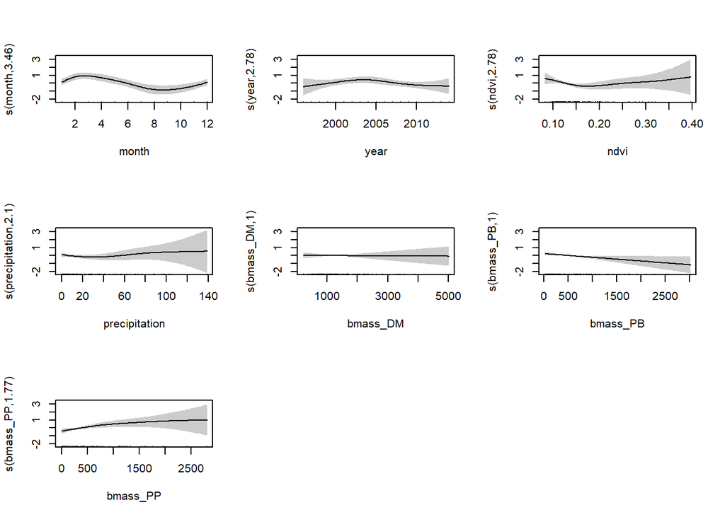

```r
#best fit plot####
plot(m1_bmass2, shade=T, pages=1)
```

Fig.1. Partial effects plot of the relationships between different predictor variables and the proportion of breeding male PBs in control plots estimated using a generalized additive model (GAM).

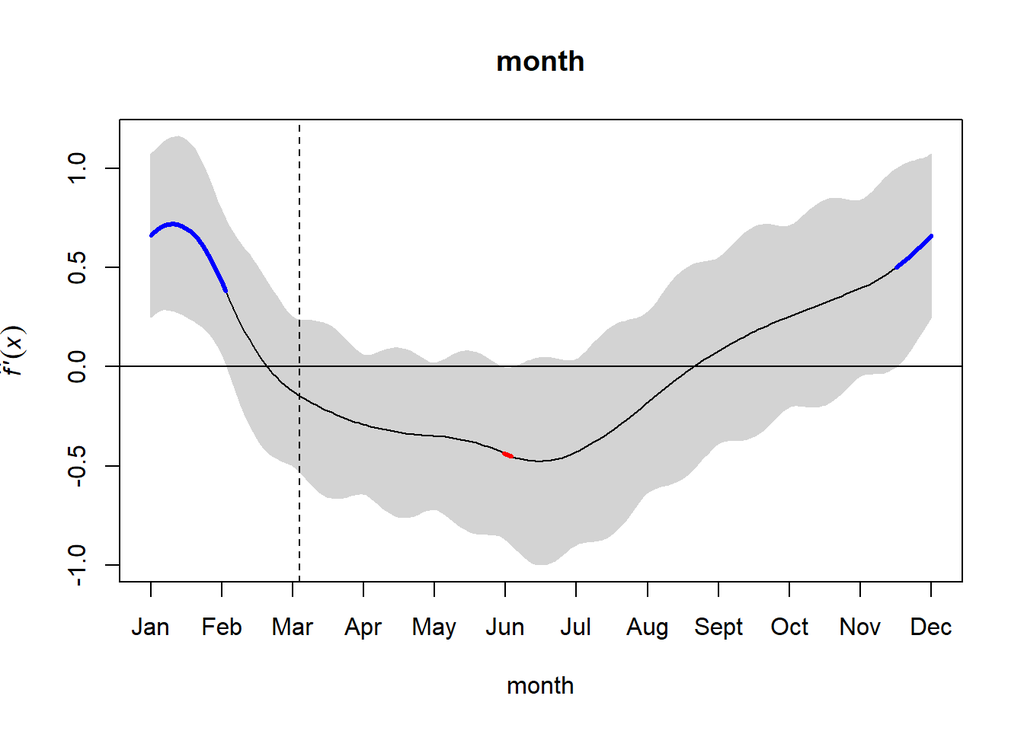

Fig.2. Periods of significant change in the seasonal trends in the reproductive phenology of breeding male Bailey’s pocket mouse (*Chaetodipus baileyi*) in control plots in a project site near Portal, Arizona. Periods of significant increase (blue) or decrease (red) are indicated by the coloured sections of the trend. Dashed vertical line indicate peak breeding period.

#### PB MALES IN EXCLOSURE

```
##
## Family: binomial
## Link function: logit
##
## Formula:
## proportion ~ s(month, bs = "cc", k = 12) + s(year) + s(ndvi) +
##     s(precipitation)
##
## Parametric coefficients:
##             Estimate Std. Error z value Pr(>|z|)
## (Intercept) -2.20810    0.09447  -23.38   <2e-16 ***
## ---
## Signif. codes:  0 '***' 0.001 '**' 0.01 '*' 0.05 '.' 0.1 ' ' 1
##
## Approximate significance of smooth terms:
##                    edf Ref.df Chi.sq  p-value
## s(month)         4.909 10.000 43.236 6.35e-10 ***
## s(year)          4.566  5.553 32.747 1.06e-05 ***
## s(ndvi)          1.411  1.717  0.727 0.518904
## s(precipitation) 1.000  1.001 14.701 0.000126 ***
## ---
## Signif. codes:  0 '***' 0.001 '**' 0.01 '*' 0.05 '.' 0.1 ' ' 1
##
## R-sq.(adj) =  0.312   Deviance explained = 33.5%
## -REML = 227.28  Scale est. = 1         n = 163
```

```
##
## Family: binomial
## Link function: logit
##
## Formula:
## proportion ~ s(month, bs = "cc", k = 12) + s(year) + s(ndvi) +
##     s(precipitation) + s(bmass_DM) + s(bmass_PB)
##
## Parametric coefficients:
##             Estimate Std. Error z value Pr(>|z|)
## (Intercept) -2.18882    0.09679  -22.61   <2e-16 ***
## ---
## Signif. codes:  0 '***' 0.001 '**' 0.01 '*' 0.05 '.' 0.1 ' ' 1
##
## Approximate significance of smooth terms:
##                    edf Ref.df Chi.sq  p-value
## s(month)         4.926 10.000 39.412 4.07e-09 ***
## s(year)          4.379  5.306 29.480 3.21e-05 ***
## s(ndvi)          1.441  1.763  1.039 0.433110
## s(precipitation) 1.000  1.001 12.608 0.000386 ***
## s(bmass_DM)      2.039  2.502  2.952 0.331304
## s(bmass_PB)      1.387  1.643  3.898 0.200859
## ---
## Signif. codes:  0 '***' 0.001 '**' 0.01 '*' 0.05 '.' 0.1 ' ' 1
##
## R-sq.(adj) =  0.331   Deviance explained = 35.8%
## -REML = 229.13  Scale est. = 1         n = 163
```

```
##
## Family: binomial
## Link function: logit
##
## Formula:
## proportion ~ s(month, bs = "cc", k = 12) + s(year) + s(ndvi) +
##     s(precipitation) + s(bmass_DM) + s(bmass_PB) + s(bmass_PP)
##
## Parametric coefficients:
##             Estimate Std. Error z value Pr(>|z|)
## (Intercept)   -2.246      0.100  -22.45   <2e-16 ***
## ---
## Signif. codes:  0 '***' 0.001 '**' 0.01 '*' 0.05 '.' 0.1 ' ' 1
##
## Approximate significance of smooth terms:
##                    edf Ref.df Chi.sq  p-value
## s(month)         4.672 10.000 42.604 1.48e-10 ***
## s(year)          4.808  5.828 47.572 2.06e-08 ***
## s(ndvi)          1.460  1.787  1.683 0.295241
## s(precipitation) 1.000  1.000 14.073 0.000176 ***
## s(bmass_DM)      1.465  1.764  2.287 0.369340
## s(bmass_PB)      1.000  1.000  9.544 0.002006 **
## s(bmass_PP)      2.236  2.775 20.603 0.000112 ***
## ---
## Signif. codes:  0 '***' 0.001 '**' 0.01 '*' 0.05 '.' 0.1 ' ' 1
##
## R-sq.(adj) =  0.395   Deviance explained = 42.8%
## -REML = 221.04  Scale est. = 1         n = 163
```

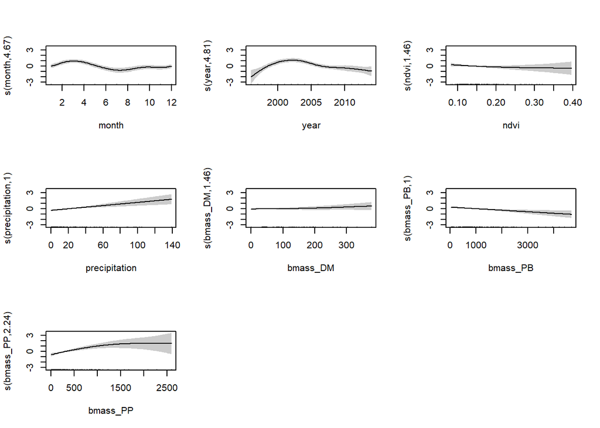

```r
#best fit plot####
plot(m2_bmass2, shade=T, pages=1)
```

Fig.3. Partial effects plot of the relationships between different predictor variables and the proportion of breeding male PBs in k-rat exclosure plots estimated using a generalized additive model (GAM).

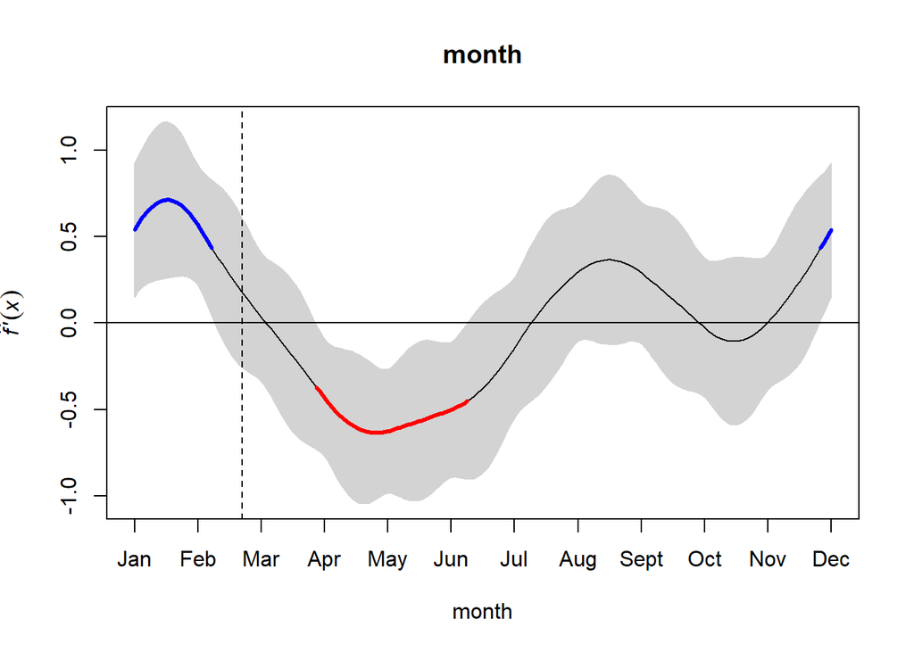

Fig.4. Periods of significant change in the seasonal trends in the reproductive phenology of breeding male Bailey’s pocket mouse (*Chaetodipus baileyi*) in k-rat exclosure plots in a project site near Portal, Arizona. Periods of significant increase (blue) or decrease (red) are indicated by the coloured sections of the trend. Dashed vertical line indicate peak breeding period.

#### PB FEMALES IN CONTROL

```
##
## Family: binomial
## Link function: logit
##
## Formula:
## proportion ~ s(month, bs = "cc", k = 12) + s(year) + s(ndvi) +
##     s(precipitation)
##
## Parametric coefficients:
##             Estimate Std. Error z value Pr(>|z|)
## (Intercept)  -2.6695     0.1712   -15.6   <2e-16 ***
## ---
## Signif. codes:  0 '***' 0.001 '**' 0.01 '*' 0.05 '.' 0.1 ' ' 1
##
## Approximate significance of smooth terms:
##                    edf Ref.df Chi.sq  p-value
## s(month)         5.227 10.000 67.400 6.37e-16 ***
## s(year)          6.410  7.392 32.109 5.97e-05 ***
## s(ndvi)          4.589  5.607 10.370   0.0981 .
## s(precipitation) 1.000  1.000  0.865   0.3523
## ---
## Signif. codes:  0 '***' 0.001 '**' 0.01 '*' 0.05 '.' 0.1 ' ' 1
##
## R-sq.(adj) =  0.329   Deviance explained =   44%
## -REML = 175.89  Scale est. = 1         n = 148
```

```
##
## Family: binomial
## Link function: logit
##
## Formula:
## proportion ~ s(month, bs = "cc", k = 12) + s(year) + s(ndvi) +
##     s(precipitation) + s(bmass_DM) + s(bmass_PB)
##
## Parametric coefficients:
##             Estimate Std. Error z value Pr(>|z|)
## (Intercept)  -2.8735     0.2186  -13.15   <2e-16 ***
## ---
## Signif. codes:  0 '***' 0.001 '**' 0.01 '*' 0.05 '.' 0.1 ' ' 1
##
## Approximate significance of smooth terms:
##                    edf Ref.df Chi.sq  p-value
## s(month)         5.027 10.000 51.190  1.5e-12 ***
## s(year)          7.695  8.429 30.852 0.000151 ***
## s(ndvi)          1.000  1.001  0.762 0.382706
## s(precipitation) 1.000  1.000  0.259 0.610497
## s(bmass_DM)      5.442  6.605 26.347 0.000300 ***
## s(bmass_PB)      2.998  3.748  5.617 0.144004
## ---
## Signif. codes:  0 '***' 0.001 '**' 0.01 '*' 0.05 '.' 0.1 ' ' 1
##
## R-sq.(adj) =  0.479   Deviance explained = 57.6%
## -REML =  166.4  Scale est. = 1         n = 148
```

```
##
## Family: binomial
## Link function: logit
##
## Formula:
## proportion ~ s(month, bs = "cc", k = 12) + s(year) + s(ndvi) +
##     s(precipitation) + s(bmass_DM) + s(bmass_PB) + s(bmass_PP)
##
## Parametric coefficients:
##             Estimate Std. Error z value Pr(>|z|)
## (Intercept)  -2.9830     0.2136  -13.96   <2e-16 ***
## ---
## Signif. codes:  0 '***' 0.001 '**' 0.01 '*' 0.05 '.' 0.1 ' ' 1
##
## Approximate significance of smooth terms:
##                    edf Ref.df Chi.sq  p-value
## s(month)         4.953 10.000 46.184 1.22e-11 ***
## s(year)          3.463  4.216 29.833 5.62e-06 ***
## s(ndvi)          1.000  1.000  0.013   0.9101
## s(precipitation) 1.000  1.001  1.487   0.2227
## s(bmass_DM)      2.915  3.626 12.212   0.0106 *
## s(bmass_PB)      1.815  2.250  3.760   0.1827
## s(bmass_PP)      3.626  4.440 48.324 3.78e-09 ***
## ---
## Signif. codes:  0 '***' 0.001 '**' 0.01 '*' 0.05 '.' 0.1 ' ' 1
##
## R-sq.(adj) =  0.563   Deviance explained = 61.8%
## -REML = 145.24  Scale est. = 1         n = 148
```

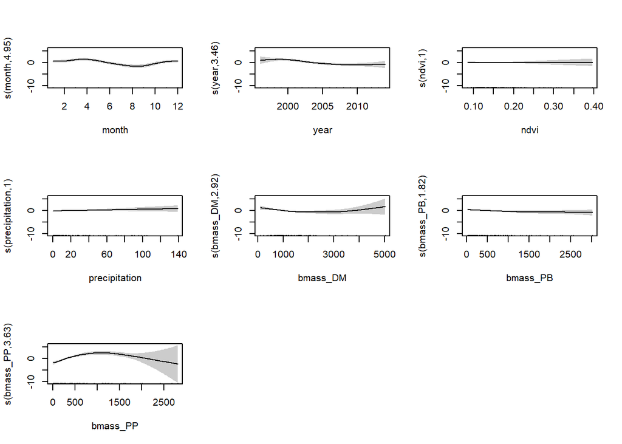

```r
#best fit plot####
plot(m3_bmass2, shade=T, pages=1)
```

Fig.5. Partial effects plot of the relationships between different predictor variables and the proportion of breeding female PBs in control plots estimated using a generalized additive model (GAM).

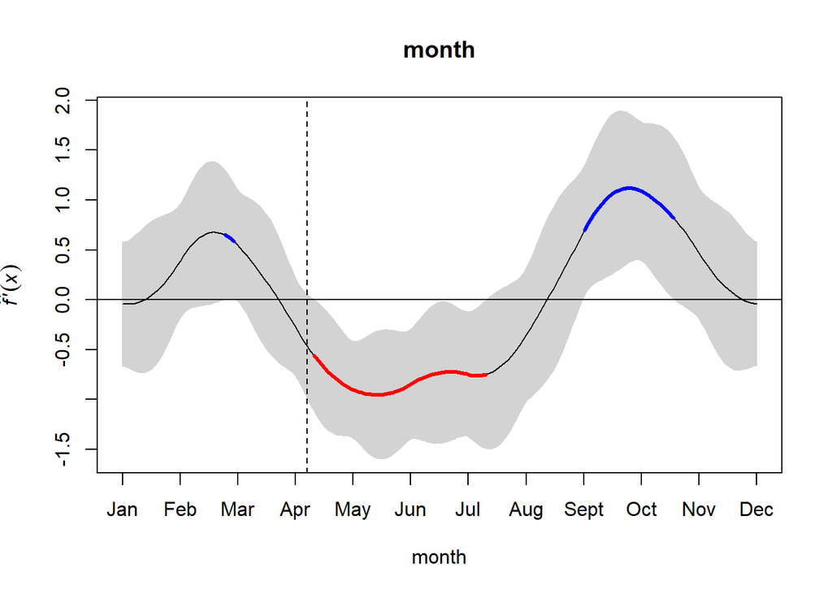

Fig.6. Periods of significant change in the seasonal trends in the reproductive phenology of breeding female Bailey’s pocket mouse (*Chaetodipus baileyi*) in control plots in a project site near Portal, Arizona. Periods of significant increase (blue) or decrease (red) are indicated by the coloured sections of the trend. Dashed vertical line indicate peak breeding period.

#### PB FEMALES IN EXCLOSURE

```
##
## Family: binomial
## Link function: logit
##
## Formula:
## proportion ~ s(month, bs = "cc", k = 12) + s(year) + s(ndvi) +
##     s(precipitation)
##
## Parametric coefficients:
##             Estimate Std. Error z value Pr(>|z|)
## (Intercept)   -2.506      0.108  -23.21   <2e-16 ***
## ---
## Signif. codes:  0 '***' 0.001 '**' 0.01 '*' 0.05 '.' 0.1 ' ' 1
##
## Approximate significance of smooth terms:
##                    edf Ref.df Chi.sq  p-value
## s(month)         6.639 10.000 188.93  < 2e-16 ***
## s(year)          6.257  7.220  98.69  < 2e-16 ***
## s(ndvi)          6.588  7.615  44.95 3.04e-07 ***
## s(precipitation) 1.000  1.001  16.34 5.30e-05 ***
## ---
## Signif. codes:  0 '***' 0.001 '**' 0.01 '*' 0.05 '.' 0.1 ' ' 1
##
## R-sq.(adj) =   0.53   Deviance explained =   57%
## -REML = 294.26  Scale est. = 1         n = 159
```

```
##
## Family: binomial
## Link function: logit
##
## Formula:
## proportion ~ s(month, bs = "cc", k = 12) + s(year) + s(ndvi) +
##     s(precipitation) + s(bmass_DM) + s(bmass_PB)
##
## Parametric coefficients:
##             Estimate Std. Error z value Pr(>|z|)
## (Intercept)  -2.4820     0.1008  -24.64   <2e-16 ***
## ---
## Signif. codes:  0 '***' 0.001 '**' 0.01 '*' 0.05 '.' 0.1 ' ' 1
##
## Approximate significance of smooth terms:
##                    edf Ref.df  Chi.sq  p-value
## s(month)         7.013 10.000 195.071  < 2e-16 ***
## s(year)          4.701  5.613  83.399 1.19e-15 ***
## s(ndvi)          1.000  1.000  14.418 0.000147 ***
## s(precipitation) 3.047  3.728  19.705 0.000351 ***
## s(bmass_DM)      4.585  5.423  40.201 5.26e-07 ***
## s(bmass_PB)      1.000  1.000   0.107 0.743179
## ---
## Signif. codes:  0 '***' 0.001 '**' 0.01 '*' 0.05 '.' 0.1 ' ' 1
##
## R-sq.(adj) =  0.562   Deviance explained = 59.2%
## -REML = 286.67  Scale est. = 1         n = 159
```

```
##
## Family: binomial
## Link function: logit
##
## Formula:
## proportion ~ s(month, bs = "cc", k = 12) + s(year) + s(ndvi) +
##     s(precipitation) + s(bmass_DM) + s(bmass_PB) + s(bmass_PP)
##
## Parametric coefficients:
##             Estimate Std. Error z value Pr(>|z|)
## (Intercept)  -2.6538     0.1269  -20.91   <2e-16 ***
## ---
## Signif. codes:  0 '***' 0.001 '**' 0.01 '*' 0.05 '.' 0.1 ' ' 1
##
## Approximate significance of smooth terms:
##                    edf Ref.df  Chi.sq  p-value
## s(month)         5.854 10.000 123.761  < 2e-16 ***
## s(year)          5.242  6.165 101.228  < 2e-16 ***
## s(ndvi)          5.140  6.093  28.606 6.45e-05 ***
## s(precipitation) 1.648  2.010  12.978  0.00155 **
## s(bmass_DM)      1.000  1.001   3.260  0.07102 .
## s(bmass_PB)      3.180  3.926   7.907  0.09454 .
## s(bmass_PP)      6.690  7.697  74.652 6.63e-13 ***
## ---
## Signif. codes:  0 '***' 0.001 '**' 0.01 '*' 0.05 '.' 0.1 ' ' 1
##
## R-sq.(adj) =  0.682   Deviance explained = 71.4%
## -REML = 262.31  Scale est. = 1         n = 159
```

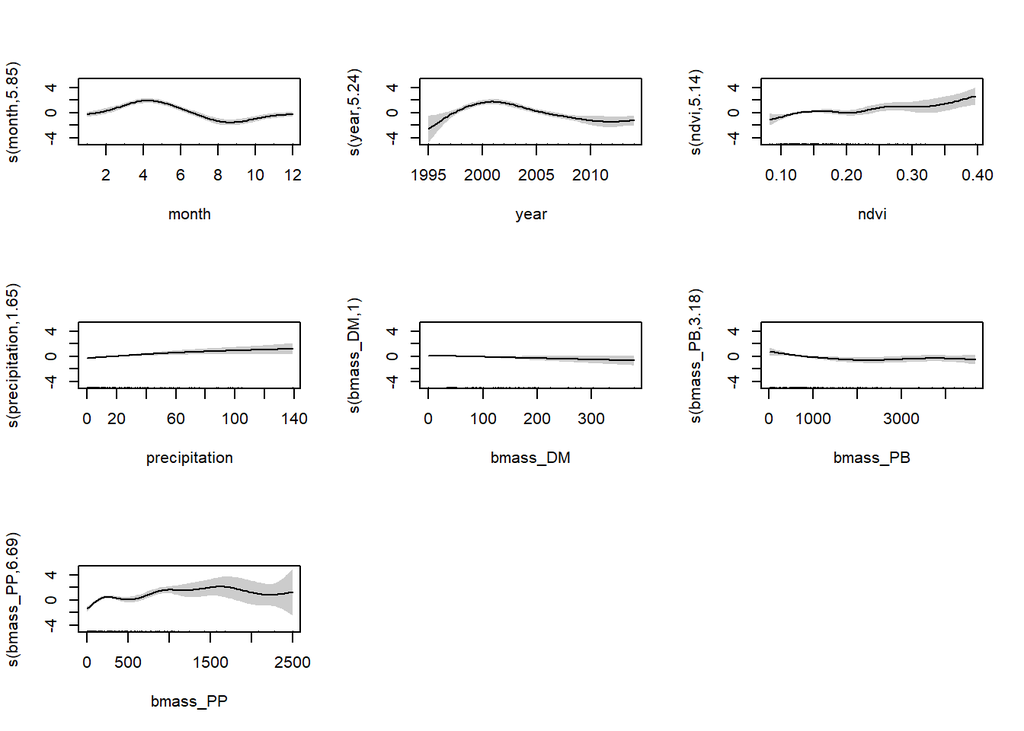

Fig.7. Partial effects plot of the relationships between different predictor variables and the proportion of breeding female PBs in k-rat exclosure plots estimated using a generalized additive model (GAM).

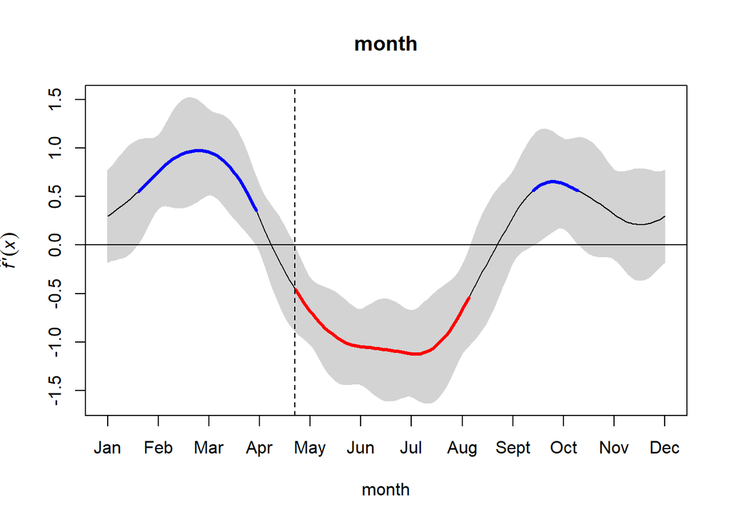

Fig.8. Periods of significant change in the seasonal trends in the reproductive phenology of breeding female Bailey’s pocket mouse (*Chaetodipus baileyi*) in k-rat exclosure plots in a project site near Portal, Arizona. Periods of significant increase (blue) or decrease (red) are indicated by the coloured sections of the trend. Dashed vertical line indicate peak breeding period.

### PP MODELS

#### PP MALES IN CONTROL

```
##
## Family: binomial
## Link function: logit
##
## Formula:
## proportion ~ s(month, bs = "cc", k = 12) + s(year) + s(ndvi) +
##     s(precipitation)
##
## Parametric coefficients:
##             Estimate Std. Error z value Pr(>|z|)
## (Intercept)  -2.4287     0.1208  -20.11   <2e-16 ***
## ---
## Signif. codes:  0 '***' 0.001 '**' 0.01 '*' 0.05 '.' 0.1 ' ' 1
##
## Approximate significance of smooth terms:
##                    edf Ref.df  Chi.sq p-value
## s(month)         5.036 10.000 109.168  <2e-16 ***
## s(year)          1.992  2.504   2.091   0.580
## s(ndvi)          2.341  2.947   4.938   0.191
## s(precipitation) 1.000  1.000   0.237   0.627
## ---
## Signif. codes:  0 '***' 0.001 '**' 0.01 '*' 0.05 '.' 0.1 ' ' 1
##
## R-sq.(adj) =  0.578   Deviance explained = 59.6%
## -REML = 203.78  Scale est. = 1         n = 187
```

```
##
## Family: binomial
## Link function: logit
##
## Formula:
## proportion ~ s(month, bs = "cc", k = 12) + s(year) + s(ndvi) +
##     s(precipitation) + s(bmass_DM) + s(bmass_PB)
##
## Parametric coefficients:
##             Estimate Std. Error z value Pr(>|z|)
## (Intercept)  -2.4541     0.1224  -20.05   <2e-16 ***
## ---
## Signif. codes:  0 '***' 0.001 '**' 0.01 '*' 0.05 '.' 0.1 ' ' 1
##
## Approximate significance of smooth terms:
##                    edf Ref.df Chi.sq p-value
## s(month)         4.861 10.000 99.080  <2e-16 ***
## s(year)          1.000  1.000  0.148   0.700
## s(ndvi)          3.522  4.351  7.378   0.108
## s(precipitation) 1.000  1.000  0.045   0.832
## s(bmass_DM)      1.508  1.823  0.696   0.579
## s(bmass_PB)      3.843  4.723  8.364   0.142
## ---
## Signif. codes:  0 '***' 0.001 '**' 0.01 '*' 0.05 '.' 0.1 ' ' 1
##
## R-sq.(adj) =  0.612   Deviance explained = 63.2%
## -REML = 206.35  Scale est. = 1         n = 187
```

```
##
## Family: binomial
## Link function: logit
##
## Formula:
## proportion ~ s(month, bs = "cc", k = 12) + s(year) + s(ndvi) +
##     s(precipitation) + s(bmass_DM) + s(bmass_PB) + s(bmass_PP)
##
## Parametric coefficients:
##             Estimate Std. Error z value Pr(>|z|)
## (Intercept)  -2.5848     0.1408  -18.36   <2e-16 ***
## ---
## Signif. codes:  0 '***' 0.001 '**' 0.01 '*' 0.05 '.' 0.1 ' ' 1
##
## Approximate significance of smooth terms:
##                    edf Ref.df Chi.sq p-value
## s(month)         5.036 10.000 95.896  <2e-16 ***
## s(year)          1.000  1.000  4.454  0.0348 *
## s(ndvi)          4.423  5.357 14.835  0.0159 *
## s(precipitation) 1.000  1.000  0.073  0.7869
## s(bmass_DM)      1.330  1.571  0.400  0.6042
## s(bmass_PB)      1.000  1.000  0.700  0.4027
## s(bmass_PP)      3.265  4.049  9.932  0.0371 *
## ---
## Signif. codes:  0 '***' 0.001 '**' 0.01 '*' 0.05 '.' 0.1 ' ' 1
##
## R-sq.(adj) =  0.643   Deviance explained = 65.2%
## -REML = 204.89  Scale est. = 1         n = 187
```

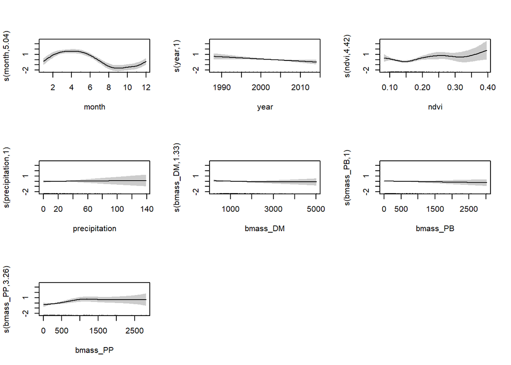

Fig.9. Partial effects plot of the relationships between different predictor variables and the proportion of breeding male PPs in control plots estimated using a generalized additive model (GAM).

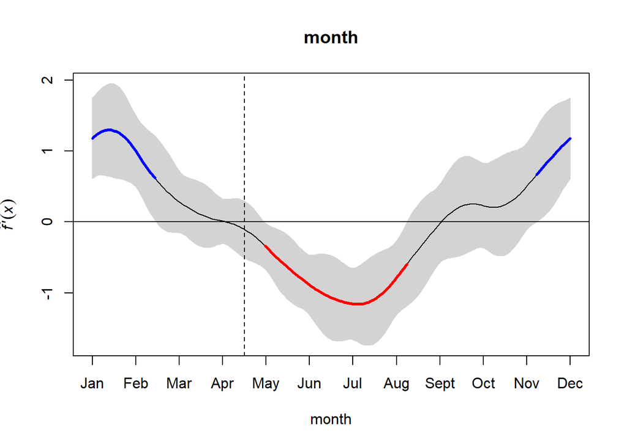

Fig.10. Periods of significant change in the seasonal trends in the reproductive phenology of breeding male desert pocket mouse (*C. penicillatus*) in control plots in a project site near Portal, Arizona. Periods of significant increase (blue) or decrease (red) are indicated by the coloured sections of the trend. Dashed vertical line indicate peak breeding period.

#### PP MALES IN EXCLOSURE

```
##
## Family: binomial
## Link function: logit
##
## Formula:
## proportion ~ s(month, bs = "cc", k = 12) + s(year) + s(ndvi) +
##     s(precipitation)
##
## Parametric coefficients:
##             Estimate Std. Error z value Pr(>|z|)
## (Intercept)   -2.358      0.119  -19.82   <2e-16 ***
## ---
## Signif. codes:  0 '***' 0.001 '**' 0.01 '*' 0.05 '.' 0.1 ' ' 1
##
## Approximate significance of smooth terms:
##                    edf Ref.df Chi.sq p-value
## s(month)         4.904 10.000 87.794  <2e-16 ***
## s(year)          1.000  1.001  0.230   0.631
## s(ndvi)          1.407  1.708  0.421   0.647
## s(precipitation) 1.000  1.000  0.508   0.476
## ---
## Signif. codes:  0 '***' 0.001 '**' 0.01 '*' 0.05 '.' 0.1 ' ' 1
##
## R-sq.(adj) =  0.507   Deviance explained = 51.6%
## -REML = 204.77  Scale est. = 1         n = 212
```

```
##
## Family: binomial
## Link function: logit
##
## Formula:
## proportion ~ s(month, bs = "cc", k = 12) + s(year) + s(ndvi) +
##     s(precipitation) + s(bmass_DM) + s(bmass_PB)
##
## Parametric coefficients:
##             Estimate Std. Error z value Pr(>|z|)
## (Intercept)  -2.3693     0.1218  -19.45   <2e-16 ***
## ---
## Signif. codes:  0 '***' 0.001 '**' 0.01 '*' 0.05 '.' 0.1 ' ' 1
##
## Approximate significance of smooth terms:
##                    edf Ref.df Chi.sq p-value
## s(month)         4.745 10.000 76.034  <2e-16 ***
## s(year)          2.017  2.559  1.848  0.4295
## s(ndvi)          1.746  2.189  1.796  0.4798
## s(precipitation) 1.000  1.000  0.342  0.5589
## s(bmass_DM)      2.419  2.992  7.864  0.0527 .
## s(bmass_PB)      1.000  1.000  1.182  0.2770
## ---
## Signif. codes:  0 '***' 0.001 '**' 0.01 '*' 0.05 '.' 0.1 ' ' 1
##
## R-sq.(adj) =   0.53   Deviance explained = 54.9%
## -REML = 206.15  Scale est. = 1         n = 212
```

```
##
## Family: binomial
## Link function: logit
##
## Formula:
## proportion ~ s(month, bs = "cc", k = 12) + s(year) + s(ndvi) +
##     s(precipitation) + s(bmass_DM) + s(bmass_PB) + s(bmass_PP)
##
## Parametric coefficients:
##             Estimate Std. Error z value Pr(>|z|)
## (Intercept)  -2.4095     0.1326  -18.16   <2e-16 ***
## ---
## Signif. codes:  0 '***' 0.001 '**' 0.01 '*' 0.05 '.' 0.1 ' ' 1
##
## Approximate significance of smooth terms:
##                    edf Ref.df Chi.sq p-value
## s(month)         4.768 10.000 71.165  <2e-16 ***
## s(year)          1.498  1.845  0.402  0.7279
## s(ndvi)          1.586  1.964  1.313  0.4608
## s(precipitation) 1.000  1.000  0.457  0.4989
## s(bmass_DM)      2.373  2.933  7.377  0.0714 .
## s(bmass_PB)      1.000  1.000  0.794  0.3728
## s(bmass_PP)      2.900  3.592  2.071  0.4901
## ---
## Signif. codes:  0 '***' 0.001 '**' 0.01 '*' 0.05 '.' 0.1 ' ' 1
##
## R-sq.(adj) =  0.528   Deviance explained =   56%
## -REML = 207.67  Scale est. = 1         n = 212
```

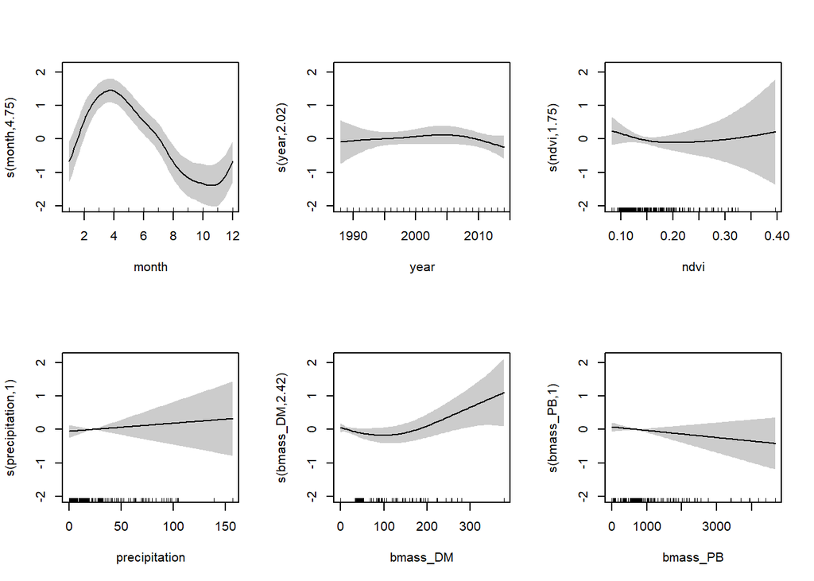

Fig.11. Partial effects plot of the relationships between different predictor variables and the proportion of breeding male PPs in k-rat exclosure plots estimated using a generalized additive model (GAM).

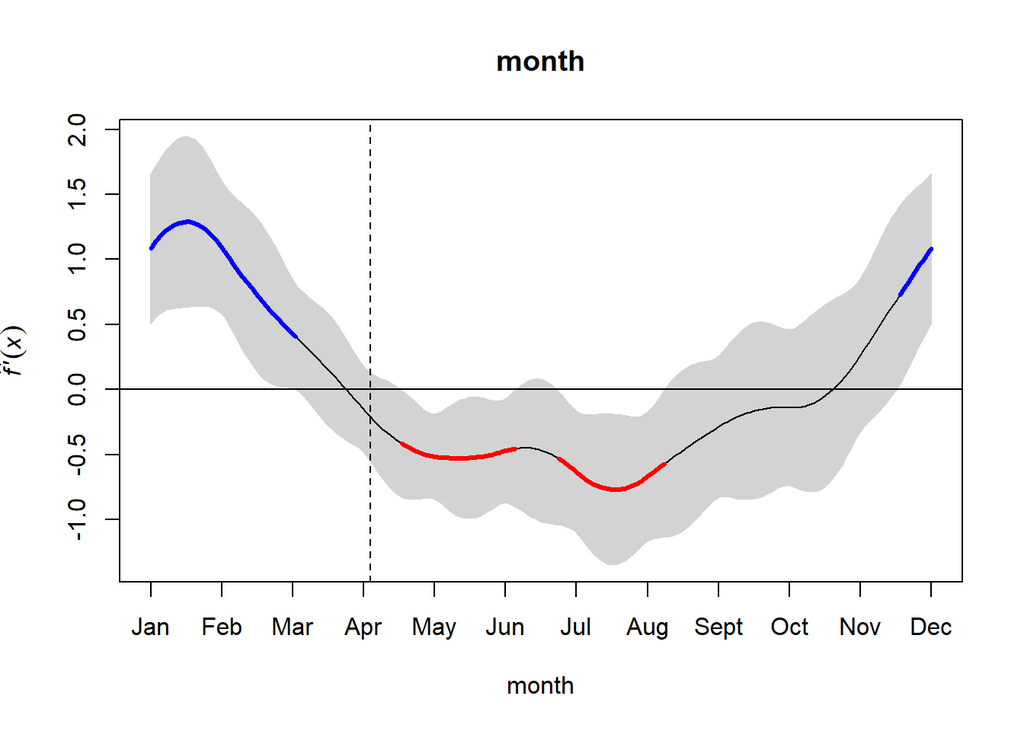

Fig.12. Periods of significant change in the seasonal trends in the reproductive phenology of breeding male desert pocket mouse (*C. penicillatus*) in k-rat exclosure plots in a project site near Portal, Arizona. Periods of significant increase (blue) or decrease (red) are indicated by the coloured sections of the trend. Dashed vertical line indicate peak breeding period.

#### PP FEMALES IN CONTROL

```
##
## Family: binomial
## Link function: logit
##
## Formula:
## proportion ~ s(month, bs = "cc", k = 12) + s(year) + s(ndvi) +
##     s(precipitation)
##
## Parametric coefficients:
##             Estimate Std. Error z value Pr(>|z|)
## (Intercept) -2.03748    0.09471  -21.51   <2e-16 ***
## ---
## Signif. codes:  0 '***' 0.001 '**' 0.01 '*' 0.05 '.' 0.1 ' ' 1
##
## Approximate significance of smooth terms:
##                    edf Ref.df Chi.sq  p-value
## s(month)         4.696 10.000 86.837  < 2e-16 ***
## s(year)          2.963  3.689 20.193  0.00056 ***
## s(ndvi)          7.646  8.474 79.949 6.89e-13 ***
## s(precipitation) 1.000  1.000  1.247  0.26433
## ---
## Signif. codes:  0 '***' 0.001 '**' 0.01 '*' 0.05 '.' 0.1 ' ' 1
##
## R-sq.(adj) =  0.456   Deviance explained = 48.1%
## -REML = 270.09  Scale est. = 1         n = 170
```

```
##
## Family: binomial
## Link function: logit
##
## Formula:
## proportion ~ s(month, bs = "cc", k = 12) + s(year) + s(ndvi) +
##     s(precipitation) + s(bmass_DM) + s(bmass_PB)
##
## Parametric coefficients:
##             Estimate Std. Error z value Pr(>|z|)
## (Intercept) -2.02769    0.09703   -20.9   <2e-16 ***
## ---
## Signif. codes:  0 '***' 0.001 '**' 0.01 '*' 0.05 '.' 0.1 ' ' 1
##
## Approximate significance of smooth terms:
##                    edf Ref.df Chi.sq  p-value
## s(month)         4.948 10.000  95.40  < 2e-16 ***
## s(year)          2.870  3.660  10.60  0.03230 *
## s(ndvi)          7.128  8.076  69.89 4.66e-12 ***
## s(precipitation) 1.000  1.000   0.18  0.67187
## s(bmass_DM)      4.120  4.993  14.25  0.01424 *
## s(bmass_PB)      1.000  1.000  10.22  0.00139 **
## ---
## Signif. codes:  0 '***' 0.001 '**' 0.01 '*' 0.05 '.' 0.1 ' ' 1
##
## R-sq.(adj) =  0.498   Deviance explained = 53.8%
## -REML = 264.82  Scale est. = 1         n = 170
```

```
##
## Family: binomial
## Link function: logit
##
## Formula:
## proportion ~ s(month, bs = "cc", k = 12) + s(year) + s(ndvi) +
##     s(precipitation) + s(bmass_DM) + s(bmass_PB) + s(bmass_PP)
##
## Parametric coefficients:
##             Estimate Std. Error z value Pr(>|z|)
## (Intercept)  -2.2145     0.1204   -18.4   <2e-16 ***
## ---
## Signif. codes:  0 '***' 0.001 '**' 0.01 '*' 0.05 '.' 0.1 ' ' 1
##
## Approximate significance of smooth terms:
##                    edf Ref.df Chi.sq  p-value
## s(month)         5.233 10.000  93.94  < 2e-16 ***
## s(year)          3.139  3.958  18.61  0.00104 **
## s(ndvi)          6.843  7.826  60.43 3.43e-10 ***
## s(precipitation) 1.000  1.000   0.20  0.65462
## s(bmass_DM)      4.373  5.276  19.84  0.00180 **
## s(bmass_PB)      1.000  1.001  18.49 1.71e-05 ***
## s(bmass_PP)      2.662  3.303  10.57  0.02121 *
## ---
## Signif. codes:  0 '***' 0.001 '**' 0.01 '*' 0.05 '.' 0.1 ' ' 1
##
## R-sq.(adj) =   0.53   Deviance explained = 57.2%
## -REML = 261.98  Scale est. = 1         n = 170
```

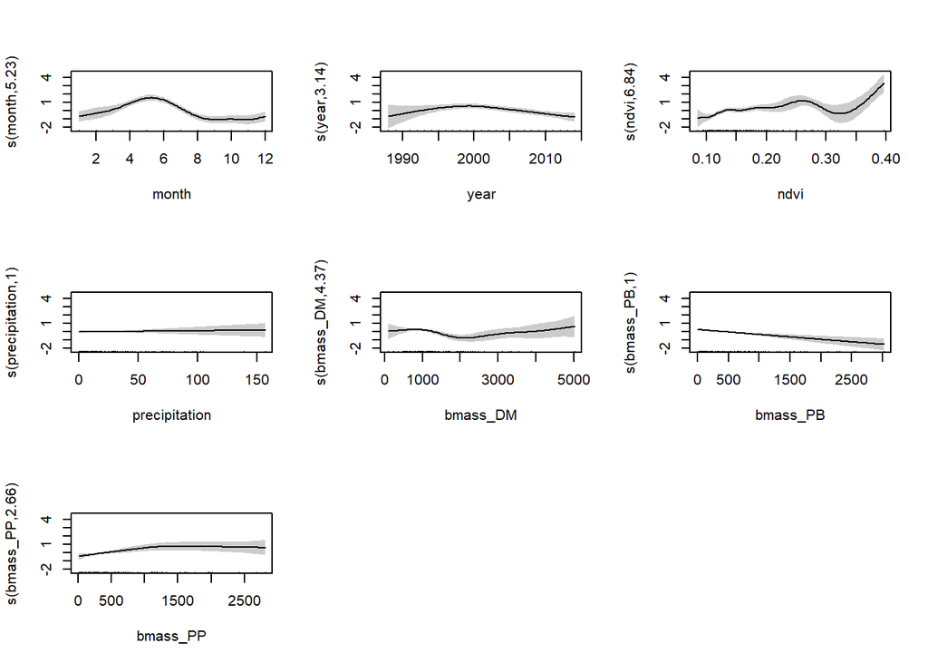

Fig. 13. Partial effects plot of the relationships between different predictor variables and the proportion of breeding female PPs in control plots estimated using a generalized additive model (GAM).

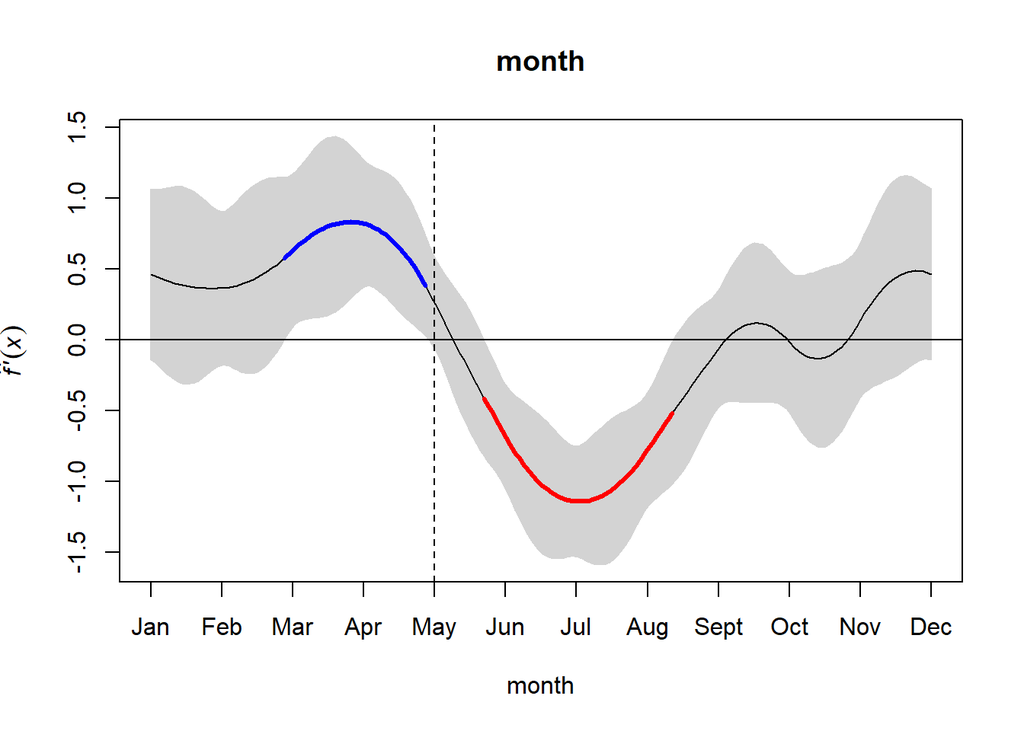

Fig.14. Periods of significant change in the seasonal trends in the reproductive phenology of breeding female desert pocket mouse (*C. penicillatus*) in control plots in a project site near Portal, Arizona. Periods of significant increase (blue) or decrease (red) are indicated by the coloured sections of the trend. Dashed vertical line indicate peak breeding period.

#### PP FEMALES IN EXCLOSURE

```
##
## Family: binomial
## Link function: logit
##
## Formula:
## proportion ~ s(month, bs = "cc", k = 12) + s(year) + s(ndvi) +
##     s(precipitation)
##
## Parametric coefficients:
##             Estimate Std. Error z value Pr(>|z|)
## (Intercept) -1.91047    0.09267  -20.62   <2e-16 ***
## ---
## Signif. codes:  0 '***' 0.001 '**' 0.01 '*' 0.05 '.' 0.1 ' ' 1
##
## Approximate significance of smooth terms:
##                    edf Ref.df Chi.sq  p-value
## s(month)         4.482 10.000 74.497  < 2e-16 ***
## s(year)          6.117  7.219 25.976 0.000567 ***
## s(ndvi)          7.160  8.111 44.739 4.47e-07 ***
## s(precipitation) 1.001  1.002  2.245 0.134774
## ---
## Signif. codes:  0 '***' 0.001 '**' 0.01 '*' 0.05 '.' 0.1 ' ' 1
##
## R-sq.(adj) =  0.346   Deviance explained = 39.5%
## -REML = 309.28  Scale est. = 1         n = 204
```

```
##
## Family: binomial
## Link function: logit
##
## Formula:
## proportion ~ s(month, bs = "cc", k = 12) + s(year) + s(ndvi) +
##     s(precipitation) + s(bmass_DM) + s(bmass_PB)
##
## Parametric coefficients:
##             Estimate Std. Error z value Pr(>|z|)
## (Intercept)  -2.0215     0.1048   -19.3   <2e-16 ***
## ---
## Signif. codes:  0 '***' 0.001 '**' 0.01 '*' 0.05 '.' 0.1 ' ' 1
##
## Approximate significance of smooth terms:
##                    edf Ref.df Chi.sq  p-value
## s(month)         4.844 10.000 74.146  < 2e-16 ***
## s(year)          7.318  8.258 61.138 7.32e-10 ***
## s(ndvi)          3.012  3.712  8.322   0.0693 .
## s(precipitation) 1.000  1.001  0.000   0.9919
## s(bmass_DM)      2.584  3.179  8.304   0.0449 *
## s(bmass_PB)      4.974  5.992 57.462 1.49e-10 ***
## ---
## Signif. codes:  0 '***' 0.001 '**' 0.01 '*' 0.05 '.' 0.1 ' ' 1
##
## R-sq.(adj) =  0.434   Deviance explained = 50.5%
## -REML =  290.9  Scale est. = 1         n = 204
```

```
##
## Family: binomial
## Link function: logit
##
## Formula:
## proportion ~ s(month, bs = "cc", k = 12) + s(year) + s(ndvi) +
##     s(precipitation) + s(bmass_DM) + s(bmass_PB) + s(bmass_PP)
##
## Parametric coefficients:
##             Estimate Std. Error z value Pr(>|z|)
## (Intercept)  -2.1690     0.1258  -17.24   <2e-16 ***
## ---
## Signif. codes:  0 '***' 0.001 '**' 0.01 '*' 0.05 '.' 0.1 ' ' 1
##
## Approximate significance of smooth terms:
##                    edf Ref.df Chi.sq  p-value
## s(month)         4.463 10.000 66.739  < 2e-16 ***
## s(year)          7.175  8.125 69.776 1.15e-11 ***
## s(ndvi)          2.616  3.236  9.657  0.02760 *
## s(precipitation) 1.000  1.000  0.031  0.86017
## s(bmass_DM)      2.565  3.152  7.568  0.06066 .
## s(bmass_PB)      3.863  4.722 52.547 4.46e-10 ***
## s(bmass_PP)      4.233  5.171 21.527  0.00055 ***
## ---
## Signif. codes:  0 '***' 0.001 '**' 0.01 '*' 0.05 '.' 0.1 ' ' 1
##
## R-sq.(adj) =  0.469   Deviance explained = 54.8%
## -REML = 284.07  Scale est. = 1         n = 204
```

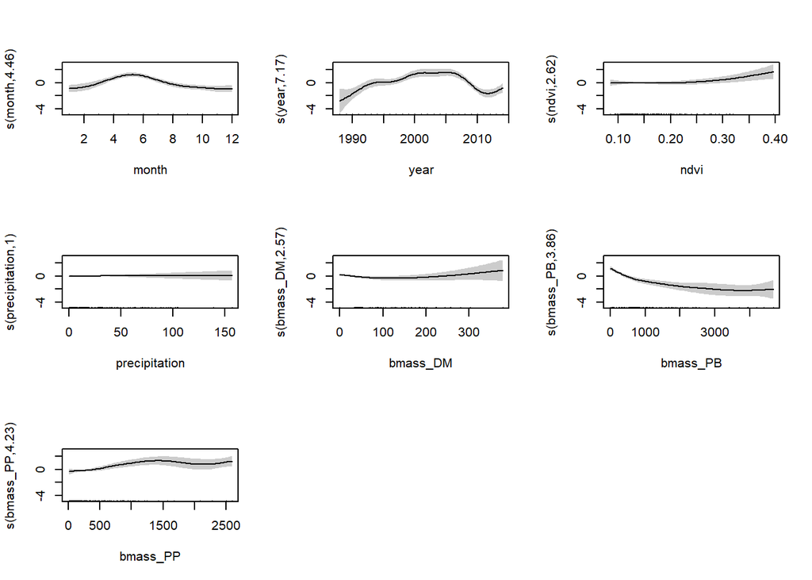

Fig.15. Partial effects plot of the relationships between different predictor variables and the proportion of breeding female PPs in k-rat exclosure plots estimated using a generalized additive model (GAM).

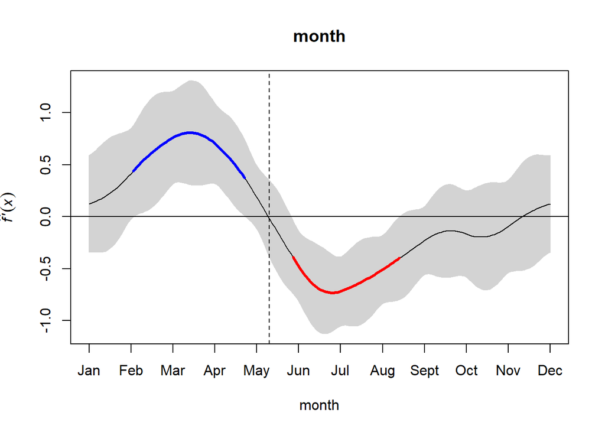

Fig.16. Periods of significant change in the seasonal trends in the reproductive phenology of breeding female desert pocket mouse (*C. penicillatus*) in k-rat exclosure plots in a project site near Portal, Arizona. Periods of significant increase (blue) or decrease (red) are indicated by the coloured sections of the trend. Dashed vertical line indicate peak breeding period.

### DM MODELS

#### DM MALES IN CONTROL

```
##
## Family: binomial
## Link function: logit
##
## Formula:
## proportion ~ s(month, bs = "cc", k = 12) + s(year) + s(ndvi) +
##     s(precipitation)
##
## Parametric coefficients:
##             Estimate Std. Error z value Pr(>|z|)
## (Intercept) -1.24126    0.03895  -31.87   <2e-16 ***
## ---
## Signif. codes:  0 '***' 0.001 '**' 0.01 '*' 0.05 '.' 0.1 ' ' 1
##
## Approximate significance of smooth terms:
##                    edf Ref.df Chi.sq  p-value
## s(month)         3.864 10.000 31.312 1.33e-07 ***
## s(year)          4.395  5.389 14.802   0.0183 *
## s(ndvi)          1.000  1.001  1.588   0.2077
## s(precipitation) 1.000  1.000  2.937   0.0866 .
## ---
## Signif. codes:  0 '***' 0.001 '**' 0.01 '*' 0.05 '.' 0.1 ' ' 1
##
## R-sq.(adj) =  0.118   Deviance explained = 13.9%
## -REML = 524.61  Scale est. = 1         n = 271
```

```
##
## Family: binomial
## Link function: logit
##
## Formula:
## proportion ~ s(month, bs = "cc", k = 12) + s(year) + s(ndvi) +
##     s(precipitation) + s(bmass_PB) + s(bmass_PP)
##
## Parametric coefficients:
##             Estimate Std. Error z value Pr(>|z|)
## (Intercept) -1.26494    0.03984  -31.75   <2e-16 ***
## ---
## Signif. codes:  0 '***' 0.001 '**' 0.01 '*' 0.05 '.' 0.1 ' ' 1
##
## Approximate significance of smooth terms:
##                    edf Ref.df Chi.sq  p-value
## s(month)         3.336 10.000 16.303 0.000276 ***
## s(year)          3.569  4.457 19.486 0.001690 **
## s(ndvi)          1.000  1.000  0.259 0.611188
## s(precipitation) 1.000  1.000  1.826 0.176676
## s(bmass_PB)      1.000  1.000  0.001 0.978184
## s(bmass_PP)      1.902  2.378 13.674 0.001986 **
## ---
## Signif. codes:  0 '***' 0.001 '**' 0.01 '*' 0.05 '.' 0.1 ' ' 1
##
## R-sq.(adj) =  0.155   Deviance explained = 16.9%
## -REML = 521.51  Scale est. = 1         n = 271
```

```
##
## Family: binomial
## Link function: logit
##
## Formula:
## proportion ~ s(month, bs = "cc", k = 12) + s(year) + s(ndvi) +
##     s(precipitation) + s(bmass_DM) + s(bmass_PB) + s(bmass_PP)
##
## Parametric coefficients:
##             Estimate Std. Error z value Pr(>|z|)
## (Intercept)  -1.2586     0.0416  -30.26   <2e-16 ***
## ---
## Signif. codes:  0 '***' 0.001 '**' 0.01 '*' 0.05 '.' 0.1 ' ' 1
##
## Approximate significance of smooth terms:
##                    edf Ref.df Chi.sq  p-value
## s(month)         3.162 10.000 14.721 0.000527 ***
## s(year)          3.386  4.259 17.195 0.003256 **
## s(ndvi)          1.000  1.000  0.272 0.602383
## s(precipitation) 1.000  1.000  1.933 0.164431
## s(bmass_DM)      1.864  2.316  2.008 0.507334
## s(bmass_PB)      1.000  1.000  0.005 0.945064
## s(bmass_PP)      1.799  2.241 12.668 0.002638 **
## ---
## Signif. codes:  0 '***' 0.001 '**' 0.01 '*' 0.05 '.' 0.1 ' ' 1
##
## R-sq.(adj) =  0.155   Deviance explained = 17.3%
## -REML = 523.59  Scale est. = 1         n = 271
```

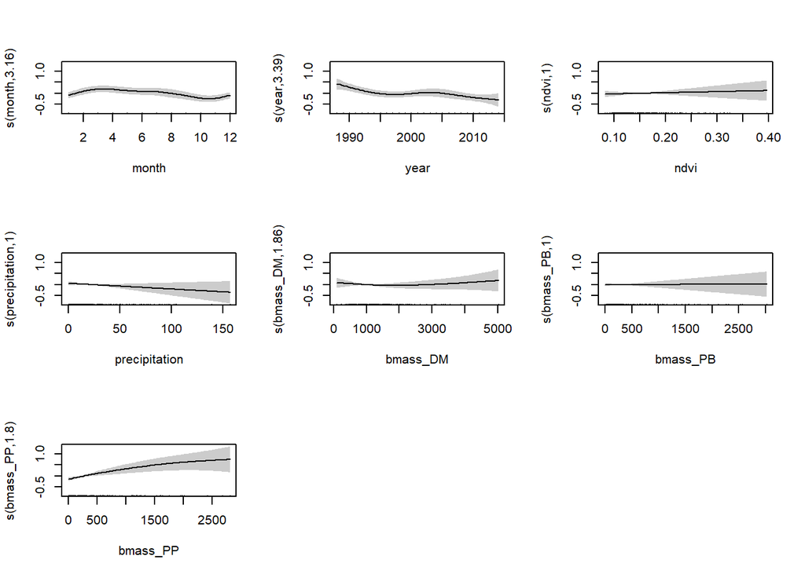

Fig.17. Partial effects plot of the relationships between different predictor variables and the proportion of breeding male DMs in control plots estimated using a generalized additive model (GAM).

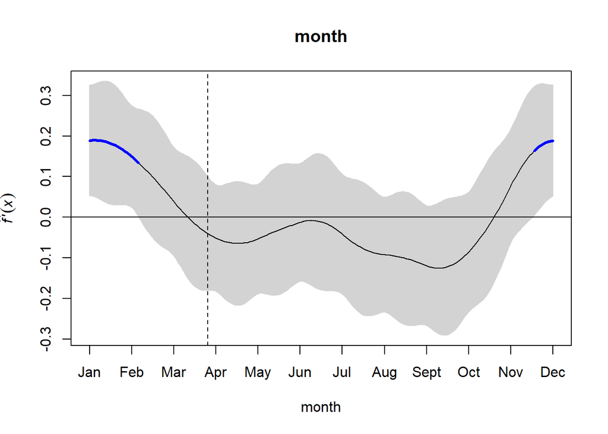

Fig.18. Periods of significant change in the seasonal trends in the reproductive phenology of breeding male kangaroo rat (*Dipodomys merriami*) in control plots in a project site near Portal, Arizona. Periods of significant increase (blue) or decrease (red) are indicated by the coloured sections of the trend. Dashed vertical line indicate peak breeding period.

#### DM FEMALES IN CONTROL

```
##
## Family: binomial
## Link function: logit
##
## Formula:
## proportion ~ s(month, bs = "cc", k = 12) + s(year) + s(ndvi) +
##     s(precipitation)
##
## Parametric coefficients:
##             Estimate Std. Error z value Pr(>|z|)
## (Intercept) -1.40334    0.05015  -27.98   <2e-16 ***
## ---
## Signif. codes:  0 '***' 0.001 '**' 0.01 '*' 0.05 '.' 0.1 ' ' 1
##
## Approximate significance of smooth terms:
##                    edf Ref.df  Chi.sq  p-value
## s(month)         4.705 10.000 115.830  < 2e-16 ***
## s(year)          7.201  8.204  39.396 5.49e-06 ***
## s(ndvi)          4.541  5.587  54.453 8.03e-10 ***
## s(precipitation) 1.000  1.001   0.143    0.706
## ---
## Signif. codes:  0 '***' 0.001 '**' 0.01 '*' 0.05 '.' 0.1 ' ' 1
##
## R-sq.(adj) =  0.347   Deviance explained =   36%
## -REML = 500.49  Scale est. = 1         n = 269
```

```
##
## Family: binomial
## Link function: logit
##
## Formula:
## proportion ~ s(month, bs = "cc", k = 12) + s(year) + s(ndvi) +
##     s(precipitation) + s(bmass_DM) + s(bmass_PB)
##
## Parametric coefficients:
##             Estimate Std. Error z value Pr(>|z|)
## (Intercept) -1.38777    0.05251  -26.43   <2e-16 ***
## ---
## Signif. codes:  0 '***' 0.001 '**' 0.01 '*' 0.05 '.' 0.1 ' ' 1
##
## Approximate significance of smooth terms:
##                    edf Ref.df  Chi.sq  p-value
## s(month)         4.645 10.000 105.585  < 2e-16 ***
## s(year)          6.975  8.034  35.730 2.11e-05 ***
## s(ndvi)          4.475  5.502  51.439 2.97e-09 ***
## s(precipitation) 1.001  1.001   0.441    0.507
## s(bmass_DM)      2.399  2.970   5.651    0.143
## s(bmass_PB)      4.589  5.618   9.817    0.115
## ---
## Signif. codes:  0 '***' 0.001 '**' 0.01 '*' 0.05 '.' 0.1 ' ' 1
##
## R-sq.(adj) =  0.374   Deviance explained = 39.3%
## -REML =  501.3  Scale est. = 1         n = 269
```

```
##
## Family: binomial
## Link function: logit
##
## Formula:
## proportion ~ s(month, bs = "cc", k = 12) + s(year) + s(ndvi) +
##     s(precipitation) + s(bmass_DM) + s(bmass_PB) + s(bmass_PP)
##
## Parametric coefficients:
##             Estimate Std. Error z value Pr(>|z|)
## (Intercept) -1.40479    0.05311  -26.45   <2e-16 ***
## ---
## Signif. codes:  0 '***' 0.001 '**' 0.01 '*' 0.05 '.' 0.1 ' ' 1
##
## Approximate significance of smooth terms:
##                    edf Ref.df Chi.sq  p-value
## s(month)         3.791 10.000 50.435 2.91e-13 ***
## s(year)          6.487  7.600 40.223 6.41e-06 ***
## s(ndvi)          4.496  5.552 34.906 5.01e-06 ***
## s(precipitation) 1.001  1.001  0.259   0.6113
## s(bmass_DM)      1.956  2.419  2.299   0.5168
## s(bmass_PB)      4.550  5.562 13.206   0.0326 *
## s(bmass_PP)      6.121  7.216 32.842 3.60e-05 ***
## ---
## Signif. codes:  0 '***' 0.001 '**' 0.01 '*' 0.05 '.' 0.1 ' ' 1
##
## R-sq.(adj) =  0.421   Deviance explained = 44.2%
## -REML = 493.61  Scale est. = 1         n = 269
```

**FOR DISCUSSION WITH MORGAN**: Not as terrible explanatory performance as DM males but surprising results: significant effect of PB and PP biomass on breeding females DMs

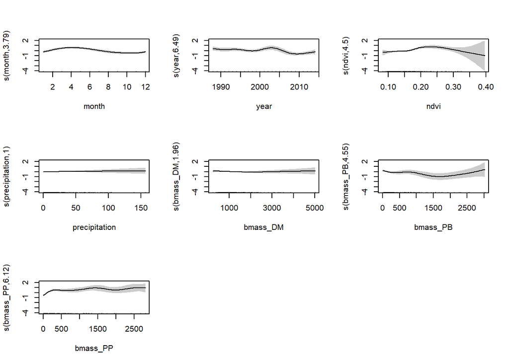

Fig.19. Partial effects plot of the relationships between different predictor variables and the proportion of breeding female DMs in control plots estimated using a generalized additive model (GAM).

### **NEXT STEPS (SUMMER TO DO LIST)**

- do manual checking of breeding data
- figure out a way to overlay the phenology plot with the first derivatives plot to make it more intuitive
- figure out an efficient way to present results to reduce number of figures (20 figures is preposterous, Pat!)
- determine how important standardizing variables are in building GAMs and interpreting them
- read Gavin’s papers to see if there are more info. we can extract from GAM outputs beyond linear/non-linear relationships
- *challenge*: implement the model in a Bayesian framework and see if the model output differs (use brms?)